# Tidybiology Final Project

Julia Palmucci

October 21, 2019

## Load libraries, such as tidyverse and tidybiology

```r
knitr::opts_chunk$set(echo = TRUE)

library(tidyverse)
library(stringr)
library(tidybiology)
library(devtools)
rm(list=ls())
```

## Import data

### Proteins

I have loaded the proteins dataset which includes protein sequence from the tidybiology library. This dataset includes the annotated protein-coding genes from the human genome. ### Subcellular location I also want to load the subcell dataset from tidybiology, which presents gene names, localization of the protein, and a confidence score.

## Take a `glimpse` into the proteins dataframe

I now want to see the variable or column names for future use.

```r
glimpse(proteins)
```

```
## Observations: 20,430
## Variables: 8
## $ uniprot_id       <chr> "P04217", "Q9NQ94", "P01023", "A8K2U0", "U3KPV4…
## $ gene_name        <chr> "A1BG", "A1CF", "A2M", "A2ML1", "A3GALT2", "A4G…
## $ gene_name_alt    <chr> NA, "ACF ASP", "CPAMD5 FWP007", "CPAMD9", "A3GA…
## $ protein_name     <chr> "Alpha-1B-glycoprotein ", "APOBEC1 complementat…
## $ protein_name_alt <chr> "Alpha-1-B glycoprotein)", "APOBEC1-stimulating…
## $ sequence         <chr> "MSMLVVFLLLWGVTWGPVTEAAIFYETQPSLWAESESLLKPLANVT…
## $ length           <dbl> 495, 594, 1474, 1454, 340, 353, 340, 546, 672, …
## $ mass             <dbl> 54254, 65202, 163291, 161107, 38754, 40499, 394…
```

## Data Analysis

I want to find all the proteins in the human genome that have a WD-repeat motif. Referencing figure 1 of Smith (2013) [accessible at: https://www.ncbi.nlm.nih.gov/books/NBK6426/figure/A76844/?report=objectonly], I identified the consensus sequence of the WD motif anchor in the sequences of the protein dataset. **[]s** mean “one of”, **|** means “or”, and **.** means “any character”

```r
str_which(proteins$sequence, "[LIVF][AVLI](S|T)[GASC][SGA].D.(T|S)[IVLA](K|R)[VLI][WFY](D|N)")
```

```
##  [1]   843  1221  1757  3062  3576  3612  3860  4140  4228  5013  5115
## [12]  5116  5865  5870  6682  6684  6685  6996  7266  8484  9896 11274
## [23] 12331 12356 12744 12927 13139 13224 13225 13673 13994 14147 15265
## [34] 16210 16389 16825 16826 16827 17045 17046 17180 17181 17182 17465
## [45] 19010 19224 19225 19234 19238 19239 19248 19249 19250 19255 19258
## [56] 19273 19277 19278 19282 19346 19347
```

I first wanted to see if my consensus sequence returned any hits. Once I knew it would, I added another column to my proteins dataset

```r
proteins <- proteins %>%
  mutate(WD_repeat = str_detect(sequence,"[LIVF][AVLI](S|T)[GASC][SGA].D.(T|S)[IVLA](K|R)[VLI][WFY](D|N)"))
glimpse(proteins)
```

```
## Observations: 20,430
## Variables: 9
## $ uniprot_id       <chr> "P04217", "Q9NQ94", "P01023", "A8K2U0", "U3KPV4…
## $ gene_name        <chr> "A1BG", "A1CF", "A2M", "A2ML1", "A3GALT2", "A4G…
## $ gene_name_alt    <chr> NA, "ACF ASP", "CPAMD5 FWP007", "CPAMD9", "A3GA…
## $ protein_name     <chr> "Alpha-1B-glycoprotein ", "APOBEC1 complementat…
## $ protein_name_alt <chr> "Alpha-1-B glycoprotein)", "APOBEC1-stimulating…
## $ sequence         <chr> "MSMLVVFLLLWGVTWGPVTEAAIFYETQPSLWAESESLLKPLANVT…
## $ length           <dbl> 495, 594, 1474, 1454, 340, 353, 340, 546, 672, …
## $ mass             <dbl> 54254, 65202, 163291, 161107, 38754, 40499, 394…
## $ WD_repeat        <lgl> FALSE, FALSE, FALSE, FALSE, FALSE, FALSE, FALSE…
```

#Filtering my data This returned a new column telling me whether a protein does (TRUE) or does not (FALSE) have my WD consensus sequence. I only care about the **TRUE** values, so I will filter them out.

```r
WD_proteins <- proteins %>%
  filter(WD_repeat == "TRUE")
glimpse(WD_proteins)
```

```
## Observations: 61
## Variables: 9
## $ uniprot_id       <chr> "O14727", "Q676U5", "Q9Y297", "Q96MR6", "P53621…
## $ gene_name        <chr> "APAF1", "ATG16L1", "BTRC", "CFAP57", "COPA", "…
## $ gene_name_alt    <chr> "KIAA0413", "APG16L UNQ9393/PRO34307", "BTRCP F…
## $ protein_name     <chr> "Apoptotic protease-activating factor 1 ", "Aut…
## $ protein_name_alt <chr> "APAF-1)", "APG16-like 1)", "E3RSIkappaB) (Epid…
## $ sequence         <chr> "MDAKARNCLLQHREALEKDIKTSYIMDHMISDGFLTISEEEKVRNE…
## $ length           <dbl> 1248, 607, 605, 1250, 1224, 925, 431, 415, 427,…
## $ mass             <dbl> 141840, 68265, 68867, 144961, 138346, 100605, 4…
## $ WD_repeat        <lgl> TRUE, TRUE, TRUE, TRUE, TRUE, TRUE, TRUE, TRUE,…
```

It worked, now I have 61 observations of 9 variables instead of 20,000!

## Integrating dataframes

I am interested in knowing more about the protein localization, so I am going to utilize the subcell dataframe. First, I need to know what variables I am working with:

```r
glimpse(subcell)
```

```
## Observations: 20,840
## Variables: 5
## $ ensembl_prot_id <chr> "18S_rRNA", "28S_rRNA", "45S_rRNA", "5S_rRNA", "…
## $ gene_name       <chr> "18S_rRNA", "28S_rRNA", "45S_rRNA", "5S_rRNA", "…
## $ go_term         <chr> "GO:0005840", "GO:0005840", "GO:0005730", "GO:00…
## $ score           <dbl> 3.389, 3.213, 2.183, 3.276, 2.561, 5.000, 5.000,…
## $ location        <chr> "Ribosome", "Ribosome", "Nucleolus", "Ribosome",…
```

```r
glimpse(WD_proteins)
```

```
## Observations: 61
## Variables: 9
## $ uniprot_id       <chr> "O14727", "Q676U5", "Q9Y297", "Q96MR6", "P53621…
## $ gene_name        <chr> "APAF1", "ATG16L1", "BTRC", "CFAP57", "COPA", "…
## $ gene_name_alt    <chr> "KIAA0413", "APG16L UNQ9393/PRO34307", "BTRCP F…
## $ protein_name     <chr> "Apoptotic protease-activating factor 1 ", "Aut…
## $ protein_name_alt <chr> "APAF-1)", "APG16-like 1)", "E3RSIkappaB) (Epid…
## $ sequence         <chr> "MDAKARNCLLQHREALEKDIKTSYIMDHMISDGFLTISEEEKVRNE…
## $ length           <dbl> 1248, 607, 605, 1250, 1224, 925, 431, 415, 427,…
## $ mass             <dbl> 141840, 68265, 68867, 144961, 138346, 100605, 4…
## $ WD_repeat        <lgl> TRUE, TRUE, TRUE, TRUE, TRUE, TRUE, TRUE, TRUE,…
```

I want to create a new dataframe that only has my WD proteins and their subcellular localization. Since both datasets share a “gene name” variable, I will use that to join my dataframes. The `inner_join` function will allow me to keep only what I am interested in.

```r
WD_localization <- inner_join(WD_proteins, subcell, by = "gene_name")
WD_localization #open the dataframe
```

| uniprot_id | gene_name | gene_name_alt | protein_name | protein_name_alt | sequence | length | mass | WD_repeat | ensembl_prot_id | go_term | score | location |
| --- | --- | --- | --- | --- | --- | --- | --- | --- | --- | --- | --- | --- |
| O14727 | APAF1 | KIAA0413 | Apoptotic protease-activating factor 1 | APAF-1) | MDAKARNCLLQHREALEKDIKTSYIMDHMISDGFLTISEEEKVRNEPTQQQRAAMLIKMI…… | 1248 | 141840 | TRUE | ENSP00000448165 | GO:0005737 | 5.000 | Cytoplasm |
| Q676U5 | ATG16L1 | APG16L UNQ9393/PRO34307 | Autophagy-related protein 16-1 | APG16-like 1) | MSSGLRAADFPRWKRHISEQLRRRDRLQRQAFEEIILQYNKLLEKSDLHSVLAQKLQAEK…… | 607 | 68265 | TRUE | ENSP00000375872 | GO:0044444 | 4.620 | Cytoplasm |
| Q9Y297 | BTRC | BTRCP FBW1A FBXW1A | F-box/WD repeat-containing protein 1A | E3RSIkappaB) (Epididymis tissue protein Li 2a) (F-box and WD repeats protein beta-TrCP) (pIkappaBalpha-E3 receptor subunit) | MDPAEAVLQEKALKFMCSMPRSLWLGCSSLADSMPSLRCLYNPGTGALTAFQNSSEREDC…… | 605 | 68867 | TRUE | ENSP00000359206 | GO:0005737 | 4.814 | Cytoplasm |
| Q96MR6 | CFAP57 | WDR65 | Cilia- and flagella-associated protein 57 | WD repeat-containing protein 65) | MSAVVAQTLHVFGLRSHVANNIFYFDEQIIIFPSGNHCVKYNVDQKWQKFIPGSEKSQGM…… | 1250 | 144961 | TRUE | ENSP00000479773 | GO:0005737 | 4.188 | Cytoplasm |
| P53621 | COPA | NA | Coatomer subunit alpha | Alpha-coat protein) (Alpha-COP) (HEP-COP) (HEPCOP) [Cleaved into: Xenin (Xenopsin-related peptide); Proxenin] | MLTKFETKSARVKGLSFHPKRPWILTSLHNGVIQLWDYRMCTLIDKFDEHDGPVRGIDFH…… | 1224 | 138346 | TRUE | ENSP00000357048 | GO:0005737 | 5.000 | Cytoplasm |
| P57737 | CORO7 | NA | Coronin-7 | Crn7) (70 kDa WD repeat tumor rejection antigen homolog) | MNRFRVSKFRHTEARPPRRESWISDIRAGTAPSCRNHIKSSCSLIAFNSDRPGVLGIVPL…… | 925 | 100605 | TRUE | ENSP00000251166 | GO:0005737 | 5.000 | Cytoplasm |
| Q05048 | CSTF1 | NA | Cleavage stimulation factor subunit 1 | CF-1 50 kDa subunit) (Cleavage stimulation factor 50 kDa subunit) (CSTF 50 kDa subunit) (CstF-50) | MYRTKVGLKDRQQLYKLIISQLLYDGYISIANGLINEIKPQSVCAPSEQLLHLIKLGMEN…… | 431 | 48358 | TRUE | ENSP00000217109 | GO:0005634 | 5.000 | Nucleus |
| Q8N136 | DAW1 | WDR69 | Dynein assembly factor with WDR repeat domains 1 | Outer row dynein assembly protein 16 homolog) (WD repeat-containing protein 69) | MKLKSLLLRYYPPGIMLEYEKHGELKTKSIDLLDLGPSTDVSALVEEIQKAEPLLTASRT…… | 415 | 45777 | TRUE | ENSP00000311899 | GO:0005929 | 3.675 | Other |
| Q92466 | DDB2 | NA | DNA damage-binding protein 2 | DDB p48 subunit) (DDBb) (Damage-specific DNA-binding protein 2) (UV-damaged DNA-binding protein 2) (UV-DDB 2) | MAPKKRPETQKTSEIVLRPRNKRSRSPLELEPEAKKLCAKGSGPSRRCDSDCLWVGLAGP…… | 427 | 47864 | TRUE | ENSP00000256996 | GO:0005634 | 4.805 | Nucleus |
| Q13347 | EIF3I | EIF3S2 TRIP1 | Eukaryotic translation initiation factor 3 subunit I | eIF3i) (Eukaryotic translation initiation factor 3 subunit 2) (TGF-beta receptor-interacting protein 1) (TRIP-1) (eIF-3-beta) (eIF3 p36) | MKPILLQGHERSITQIKYNREGDLLFTVAKDPIVNVWYSVNGERLGTYMGHTGAVWCVDA…… | 325 | 36502 | TRUE | ENSP00000362688 | GO:0005737 | 5.000 | Cytoplasm |

[output cut: 47 more lines]

## Representing this information visually

I created a bar graph to describe the number of WD proteins found in each subcellular location. The trickiest part was filling the bars according to the score. I wanted a gradient, which showed the highest scores as the most opaque and obvious color. For some reason, this was incredibly difficult.

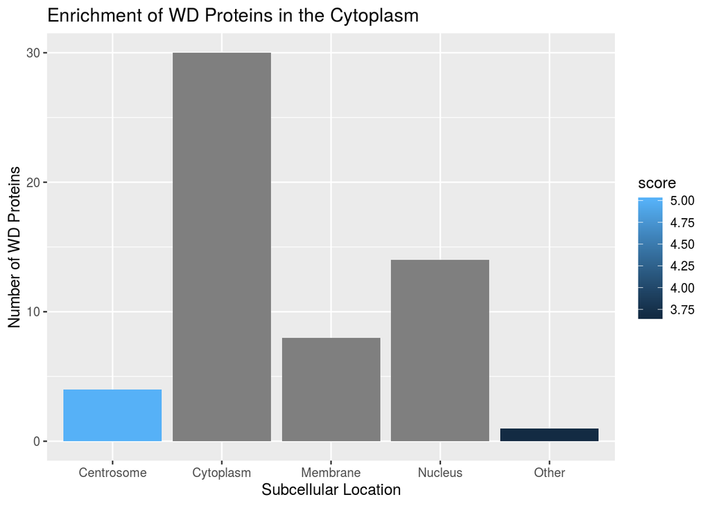

```r
k <- ggplot(WD_localization, aes(factor(location), fill = score))
k + geom_bar() +
  labs(x = "Subcellular Location", y = "Number of WD Proteins", title = "Enrichment of WD Proteins in the Cytoplasm") +
  scale_fill_gradient()
```

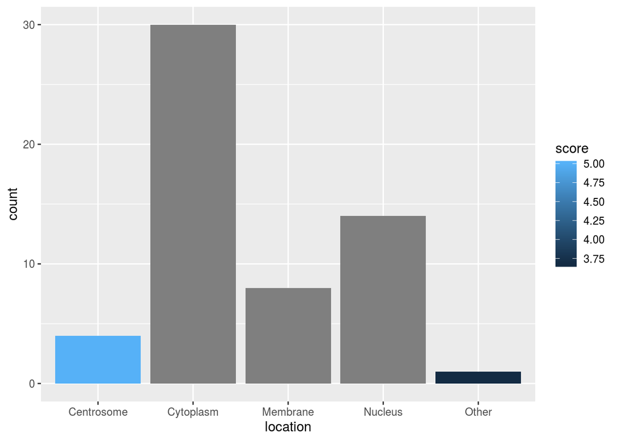

```r
#the scale_fill_gradient did not seem to do much of anything in my code
ggplot(data = WD_localization) +
  geom_bar(mapping = aes(x = location, fill = score))
```

## Final Graphs

### WD Protein and Localization

I found that `scale_fill_grey` worked, even if the continuous and gradient shading did not. I filled the bars based on “Score”, which resulted in a nice shading.

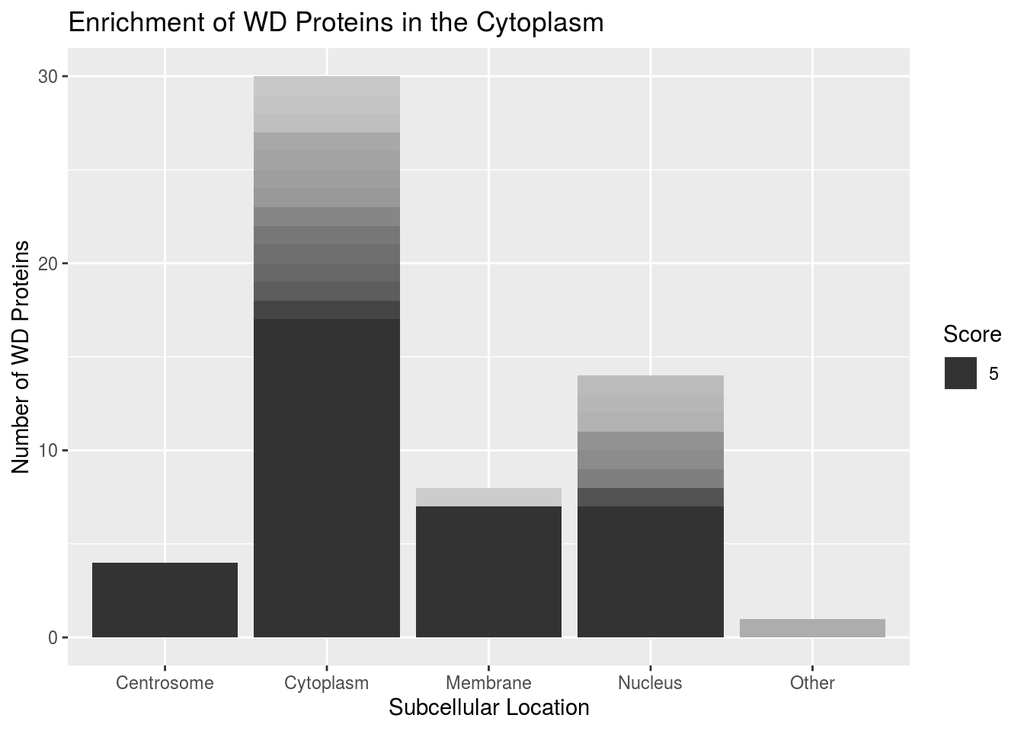

```r
WDLocal <- ggplot(WD_localization, aes(factor(location), fill = factor(score)))
WDLocal + geom_bar() +
  labs(x = "Subcellular Location", y = "Number of WD Proteins", title = "Enrichment of WD Proteins in the Cytoplasm") +
  scale_fill_grey(start = 0.8, end = 0.2, breaks = 5, "Score") #starting with 0.8 and ending with 0.2 set the highest value to the darkest color
```

```r
ggsave("WDLocal.png")
```

### WD Proteins, Size, and Localization

I then wanted to look more closely at the confidence score I had a tricky time working with. Instead of a bar plot, I chose a scatter plot using the jitter function to avoid overlapping points. I then based the size of the points on the length of the protein to give the graph another dimension.

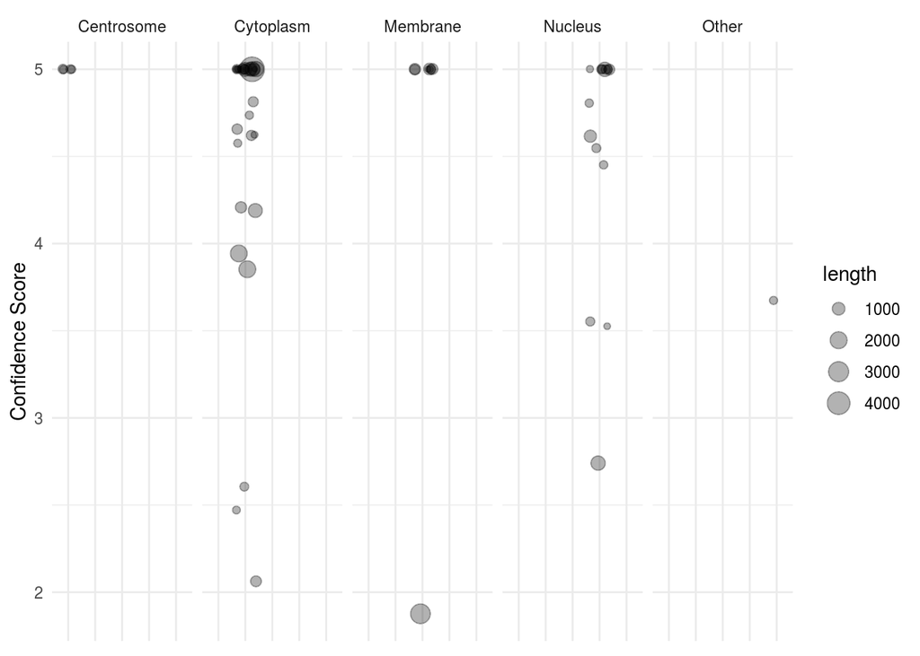

```r
ggplot(WD_localization) +
  geom_jitter(aes(x= location, y = score, size = length), alpha = 0.3) + #transparency for easier viewing) +
  facet_grid(. ~ location) + #split my graph based on organelle
  labs (x = NULL, y = "Confidence Score") +
  theme_minimal()+
  theme(axis.text.x = element_blank(), axis.ticks = element_blank())+ #remove the x axis ticks and labels
  ggsave("WDLocalxLength.png")
```

## Prioritized follow-up studies

WD proteins act as scaffold. Therefore, their enrichment in the cytoplasm was expected. However, it was interesting to see a large number of small WD proteins in the nucleus, many of which have no described function. I would follow-up on this subset of proteins by tagging them and then conducting a co-immunoprecipitation assay to isolate possible binding partners. It would be interested to find out what complexes these proteins are acting as a scaffold for.

## Acknolwedgements

I referenced Akshay Bareja’s “Introduction to dplyr” heavily while figuring out how to merge my dataframes. I also could not have done this without Stack Overflow and the wonderful instruction by Matt, Allie, and Akshay!